# PeerAssignment1

Carlosjunior4763

Monday, October 12, 2015

# Personal Movement Analysis

## About

It is now possible to collect a large amount of data about personal movement using activity monitoring devices such as a [Fitbit](https://www.fitbit.com/), [Nike Fuelband](http://www.nike.com/us/en_us/c/nikeplus-fuel), or [Jawbone Up](https://jawbone.com/up/app).

This assignment makes use of data from a personal activity monitoring device. This device collects data at 5 minute intervals through out the day. The data consists of two months of data from an anonymous individual collected during the months of October and November, 2012 and include the number of steps taken in 5 minute intervals each day.

## Data

Data for assignment was downloaded from the course web site:

Dataset: [Activity monitoring data](http://d396qusza40orc.cloudfront.net/repdata%2Fdata%2Factivity.zip) 52K

## Assignment

Get and analyse data * loading and preprocessing data * complete missing values * data analysis to answer assignement questions

## Loading and preprocessing the data

```r
rm(list=ls()) # clean work area

if(!file.exists('activity.csv')) {  ## get file
        work <- tempfile()
        download.file("http://d396qusza40orc.cloudfront.net/repdata%2Fdata%2Factivity.zip",work)
        unzip(work)
        unlink(work)}
act  <- read.csv('activity.csv') ## get data
```

## inspect data received

```r
summary(act) ## examine data
```

```
##      steps                date          interval
##  Min.   :  0.00   2012-10-01:  288   Min.   :   0.0
##  1st Qu.:  0.00   2012-10-02:  288   1st Qu.: 588.8
##  Median :  0.00   2012-10-03:  288   Median :1177.5
##  Mean   : 37.38   2012-10-04:  288   Mean   :1177.5
##  3rd Qu.: 12.00   2012-10-05:  288   3rd Qu.:1766.2
##  Max.   :806.00   2012-10-06:  288   Max.   :2355.0
##  NA's   :2304     (Other)   :15840
```

```r
nrow(act)
```

```
## [1] 17568
```

```r
head(act)
```

```
##   steps       date interval
## 1    NA 2012-10-01        0
## 2    NA 2012-10-01        5
## 3    NA 2012-10-01       10
## 4    NA 2012-10-01       15
## 5    NA 2012-10-01       20
## 6    NA 2012-10-01       25
```

```r
tail(act)
```

```
##       steps       date interval
## 17563    NA 2012-11-30     2330
## 17564    NA 2012-11-30     2335
## 17565    NA 2012-11-30     2340
## 17566    NA 2012-11-30     2345
## 17567    NA 2012-11-30     2350
## 17568    NA 2012-11-30     2355
```

```r
str(act)
```

```
## 'data.frame':    17568 obs. of  3 variables:
##  $ steps   : int  NA NA NA NA NA NA NA NA NA NA ...
##  $ date    : Factor w/ 61 levels "2012-10-01","2012-10-02",..: 1 1 1 1 1 1 1 1 1 1 ...
##  $ interval: int  0 5 10 15 20 25 30 35 40 45 ...
```

Inspection of the data shows the need to extract NA´s steps and also coerse to data format.

```r
act$date <- as.Date(as.character(act$date, format ="%Y/%m/%d")) ## coerse to data format
actc <- subset(act, !is.na(steps))  ## extract NA´s steps
```

## What is mean total number of steps taken per day?

Calculate and plot the total number of steps taken per day

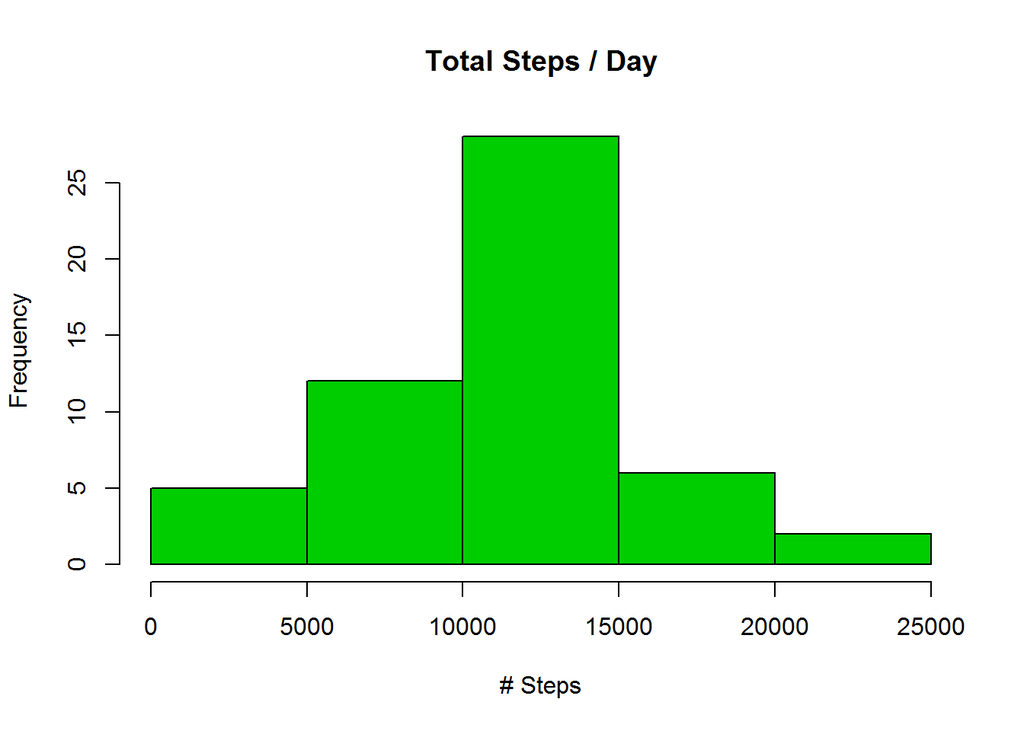

```r
steps_date <- aggregate(steps ~ date, actc, sum)
hist(steps_date$steps,
     main = paste("Total Steps / Day"),
     col=3, xlab="# Steps")
```

Calculate and report the mean and median of the total number of steps taken per day

```r
rmean <- mean(steps_date$steps)
rmedian <- median(steps_date$steps)
```

## What is the average daily activity pattern?

Calculate and plot the steps per aggregate, taken per day

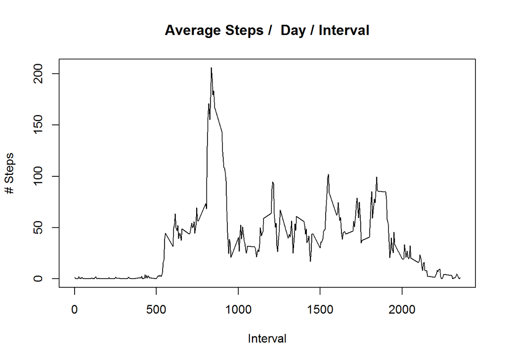

```r
steps_inter <- aggregate(steps ~ interval, actc, mean)

plot(steps_inter$interval,
     steps_inter$steps, type="l",
     xlab="Interval", ylab="# Steps",
     main="Average Steps /  Day / Interval")
```

```r
inter_max <- steps_inter[which.max(steps_inter$steps),1]
```

## Imputing missing values

Note that there are a number of days/intervals where there are missing values (coded as NA). The presence of missing days may introduce bias into some calculations or summaries of the data.

Identify the incompleted cases

```r
no_complete   <- sum(!complete.cases(act))   ##  - uses the original file with NAs
```

- the total number of missing values in the dataset is: 2304

Fill the incompleted cases

```r
complete_data <- transform(act, steps = ifelse(is.na(act$steps),
                steps_inter$steps[match(act$interval,
                steps_inter$interval)], act$steps))
complete_data[as.character(complete_data$date) == "2012-10-01", 1] <- 0
steps_date_i <- aggregate(steps ~ date, complete_data, sum)
```

Calculate new mean and median for imputed data.

```r
mean_comp <- mean(steps_date_i$steps)
median_comp <- median(steps_date_i$steps)
```

Calculate difference between imputed and non-imputed data.

```r
mean_diff <- mean_comp - rmean
```

- difference between imputed and non-imputed data is: -176.4948964

## Are there differences in activity patterns between weekdays and weekends?

Create a new factor variable in the dataset with two levels - “weekday” and “weekend” indicating whether a given date is a weekday or weekend day.

```r
# Create a factor variable with two levels (weekday, weekend-day)
workLT <- as.POSIXlt(act$date, format = "%Y-%m-%d")
workWD <- workLT$wday
workWD[workWD == 0] = 0
workWD[workWD == 6] = 0
workWD[workWD != 0] = 1
workWDFactor <- factor(workWD, levels = c(0, 1))

# Add the factor variable to the data
act$WD <- workWDFactor
```

Calculate the mean per week day

```r
stepsWD <- tapply(act$steps, list(act$interval, act$WD), mean,
                              na.rm = T)
```

Make a panel plot containing a time series plot (i.e. type = “l”) of the 5-minute interval (x-axis) and the average number of steps taken, averaged across all weekday days or weekend days (y-axis). See the README file in the GitHub repository to see an example of what this plot should look like using simulated data.

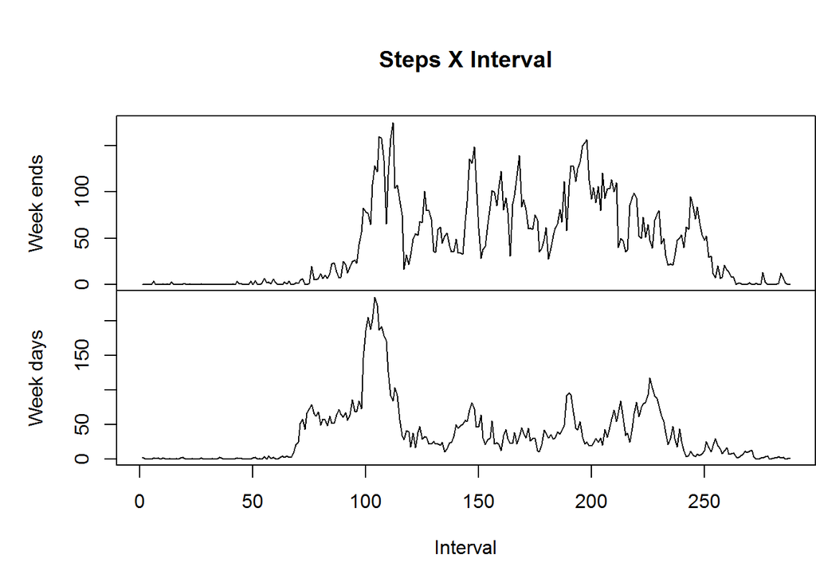

```r
par(mfrow = c(2, 1))
# Display the 2 plots
with(act, {
        par(mai = c(0, 1, 1, 0))
        plot(stepsWD[, 1], type = "l",
             main = ("Steps X Interval"),
             xaxt = "n", ylab = "Week ends")
        title = ("# of Steps v.s. Interval")
        par(mai = c(1, 1, 0, 0))
        plot(stepsWD[, 2], type = "l",
             xlab = "Interval",
             ylab = "Week days")})
```